# ЗАНЯТИЕ 7. Статистика в NumPy и в Statistics. Введение в Scipy.Stats[1]

[1] ☝🙂 Данное занятие разработано на основе англоязычного источника [13], официальной документации `Python` [8], официального руководства `Scipy` [14], `matplotlib` [15] и `plotly` [16].

## Цели занятия

Получение представления о функциональности, доступных методах и объектов статистики библиотек/модулей `NumPy`, `Statistics` и `Scipy.Stats`. Изучение основных принципов практической работы с ними.

## Порядок выполнения работы

### Статистические функции в numpy

`NumPy` имеет набор из следующих статистических функций:

1. `np.amin()` – эта функция определяет минимальное значение элемента вдоль указанной оси.
2. `np.amax()` – определяет максимальное значение элемента вдоль оси.
3. `np.mean()` – определяет среднее значение набора данных.
4. `np.median()` – определяет медианное значение набора данных.
5. `np.std()` – определяет стандартное отклонение.
6. `np.var()` – определяет дисперсию.
7. `np.ptp()` – возвращает диапазон значений по оси.
8. `np.average()` – определяет средневзвешенное значение.
9. `np.percentile()` – определяет `n`-й процентиль (персентиль или персентиль, в разных источник данный термин называется по-разному) данных по указанной оси.

Далее рассмотрим примеры работы с этими функциями.

#### Максимум и минимум массива

Пример определения минимального и максимального значения элементов массива вдоль указанной оси при помощи методов `np.amin()` и `np.amax()` показан ниже:

```python
import numpy as np

arr= np.array([[1,23,78],[98,60,75],[79,25,48]])
print(arr)
print(np.amin(arr)) # Minimum Function
print(np.amax(arr)) # Maximum Function
```

```
[[ 1 23 78]
 [98 60 75]
 [79 25 48]]
1
98
```

#### Среднее арифметическое

| $$\overline{\text{x}}\text{=}\frac{\text{1}}{\text{n}}\left( \text{x}_{\text{1}}\text{+}\text{x}_{\text{2}}\text{+…+}\text{x}_{\text{n}} \right)$$ | (1) |
| --- | --- |

Метод `np.mean()` вычисляет среднее значение, складывая все элементы массивов, а затем делит его на количество элементов. Мы также можем указать ось, по которой может быть вычислено среднее значение. Пример вычисления среднего арифметического значения представлен ниже.

```python
a = np.array([5,6,7])
print(a)
print(np.mean(a))
```

```
[5 6 7]
6.0
```

#### Медиана

Медиана (с лат. «середина» – середина множества чисел. Формула отличается для множеств с четным и нечетным числом элементов. Формула 2 – формула медианы для массивов с четным числом элементов, формула 3 – для нечетных.

| $$M_{e} = \frac{n + 1}{2}$$ | (2) |
| --- | --- |
| $$M_{e} = \frac{n}{2}$$ | (3) |

где $M_{e}$ – индекс медианного значения в ранжированном (сортированном) по возрастанию массиве, $n$ – количество элементов в этом массиве.

Рассмотрим пример с заранее отсортированном в порядке возрастания (проранжированном) массивом (вам не нужно его вручную сортировать, `np.median()` сама все отсортирует и найдет медиану, просто сейчас мы взяли уже отсортированный массив, чтобы продемонстрировать как вручную считается медианное значение). Итак, рассмотрим следующий массив (с четным числом индивидуальных значений), представленного в таблице ниже (Таблица 1):

Таблица 1. Пример массива для определения медианы

| x1 | x2 | x3 | x4 | x5 | x6 | x7 | x8 | x9 | x10 | x11 | x12 |
| --- | --- | --- | --- | --- | --- | --- | --- | --- | --- | --- | --- |
| 27.90 | 27.95 | 28.00 | 28.00 | 28.05 | 28.05 | 28.10 | 28.10 | 28.10 | 28.15 | 28.20 | 28.25 |

Для массива с нечетным числом (например, этого же массива, но без значения `х12`) элементов мы бы взяли значение с индексом `6` как значение медианы. Т.е. медианой было бы значение `28.05`.

Рассмотрим программную реализацию вычисления медианы при помощи `np.median()`. Данная функция вычисляет медиану как для одномерных, так и для многомерных массивов. При помощи медианы можно разделять верхний и нижний диапазон значений данных (относительно серединного значения), если взять её индекс.

```python
print(a)
print(np.median(a))
```

```
[5 6 7]
6.0
```

#### Среднеквадратичное (стандартное) отклонение

Среднеквадратическое отклонение (формула 4, так же называется стандартным отклонением) – определяется как квадратный корень из дисперсии случайной величины (формула 5):

| $$\sigma = \sqrt{D\lbrack x\rbrack}$$ | (4) |
| --- | --- |
| $$D\lbrack x\rbrack = \frac{\sum\left\| x - \overline{x} \right\|^{2}}{n}$$ | (5) |

где: *D*[*x*] – дисперсия случайной величины, т.е. мера разброса значений случайной величины (разброс); *σ* – стандартное отклонение.

Ниже представлена программная реализация, в которой при помощи метода `np.std()` вычисляется стандартное отклонение («std» – от англ. standart, стандартное). После этого кода будет разобрано как оно вычисляется.

```python
print(a)
print(np.std(a))
```

```
[5 6 7]
0.816496580927726
```

Вы вышестоящем коде мы получили стандартное отклонение равное `0.82`, ниже мы рассмотрим, как оно вычисляется математически (вы можете выполнить этот математический код в ячейке `Jupyter` или посчитать самостоятельно).

```python
(((5-6)**2+(6-6)**2+(7-6)**2 #Разброс от 5 до 7
)/a.size # делить на кол-во элементов 3
)**0.5 # корень квадратный
```

```
0.816496580927726
```

Как видно, результат совпадает с посчитанными при помощи метода `np.std().` Так же существует метод `np.var()`, вычисляющий разброс (т.е. дисперсию). Вычисление дисперсии представлено ниже.

```python
print(a)
print(np.var(a))
```

```
[5 6 7]
0.6666666666666666
```

Дисперсия получилась равна `0.66`, что соответствует формуле 4, в которой говорится, что стандартное отклонение это корень квадратный из дисперсии, т.е. стандартное отклонение равное `0.81` и возведенное в квадрат равно дисперсии, т.е. `0.66`.

#### Среднее взвешенное

Функция `np.average()` определяет средневзвешенное значение, и может использоваться для многомерных массивов. Средневзвешенное значение рассчитывается путем умножения компонента на его вес, веса указываются отдельно. Если веса не указаны, результат будет таким же, как и среднее значение (среднее арифметическое). Ниже представлен пример вычисления среднего взвешенного при помощи данной функции.

```python
print(a)
print(np.average(a)) # без веса то же, что и среднее

wt = np.array([8,2,3]) # массив весов
print(np.average(a, weights=wt)) # средневзвешенное значение
```

```
[5 6 7]
6.0
5.615384615384615
```

#### Процентили

Медиана представляет собой среднюю точку распределения: половина наблюдений расположена над ней, а другая половина – под ней (например, медиана чисел `[3, 4, 5, 6, 102]` составляет `5`). Термин «медиана» был рассмотрен ранее, и его суть пригодится для понимания схожего понятия «процентиль».

Процентиль (персентиль или персентиль) – это такое значение `Xp` из массива (или в терминологии статистики это называется совокупностью значений), что значения `p`-й части совокупности меньше или равны этому значению `Xp`. Мы рассмотрим, что это означает на примере программного кода ниже, но сперва рассмотрим синтаксис функции вычисления процентилей:

```
numpy.percentile (данные, q, ось)
```

где принимаются следующие параметры: `данные` – это входной массив; `q` – это процентиль (от 0 до 100), который нужно вычислить для элементов массива; `ось` – указание оси, по которой выполняется расчет.

Ниже представлен пример вычисления 67-ого процентиля для набора данных. В данном случае 67-ой процентиль определяет позицию некоторого «порогового» значения в ранжированном (отсортированном) по возрастанию ряде значений, значение которого нас интересует. Посмотрим на код, представленный ниже.

```python
a = np.array([2,5,20,20])
print(a)
print(np.percentile(a,67,0))
```

```
[ 2  5 20 20]
20.0
```

Мы можем взглянуть на это графически (Рис. 1) при помощи кода ниже:

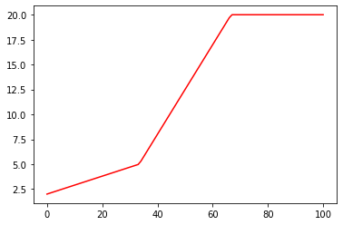

```
[ 2.    2.09  2.18  2.27  2.36  2.45  2.54  2.63  2.72  2.81  2.9   2.99
  3.08  3.17  3.26  3.35  3.44  3.53  3.62  3.71  3.8   3.89  3.98  4.07
  4.16  4.25  4.34  4.43  4.52  4.61  4.7   4.79  4.88  4.97  5.3   5.75
  6.2   6.65  7.1   7.55  8.    8.45  8.9   9.35  9.8  10.25 10.7  11.15
 11.6  12.05 12.5  12.95 13.4  13.85 14.3  14.75 15.2  15.65 16.1  16.55
 17.   17.45 17.9  18.35 18.8  19.25 19.7  20.   20.   20.   20.   20.
 20.   20.   20.   20.   20.   20.   20.   20.   20.   20.   20.   20.
 20.   20.   20.   20.   20.   20.   20.   20.   20.   20.   20.   20.
 20.   20.   20.   20.   20.  ]
```

```python
import matplotlib.pyplot as plt

percentel_arr= np.percentile(a, list(range(101)))

plt.plot(percentel_arr, color="r")
plt.show()
print (percentel_arr)
```

Рис. 1. График процентилей и значений

Из графика процентилей и значений процентилей (Рис. 1) видно, что нулевой процентиль равен 2, что значит, что ноль процентов от количества значений имеют значение меньше двух; а 100–ый процентиль равен 20, что означает, что все 100% значений ниже или равно значению 20.

Стоит отметить, что значение 50–ого процентиля равно значению медианного значения (медианы). Так же существует такое понятие, как «квартиль». Квартиль – это процентиль, который делит ряд значений на 4 равные части. Например: первый квартиль (25%) это 25–ый процентиль, а второй квартиль – это медиана или 50-ый процентиль. Квартили часто используются в бизнес-аналитике и всего лишь отражают значения четырех процентилей.

#### Полный размах

Функция `np.ptp ()` полезна для определения размаха значений вдоль оси. Ниже представлен пример.

```python
a = np.array([[2,10,20],[6,10,60]])
print(np.ptp(a,0))

b = np.array([2,10,20,5])
print(np.ptp(b,0))

b = np.array([[2,10,20,5]])
print(np.ptp(b,1))
```

```
[ 4  0 40]
18
[18]
```

Как показано в примере, можно находить размах между элементами одномерных массивов многомерного массива (пример 1), одномерного массива (пример 2, у одномерных массивов всего одна ось, и она нулевая), либо находить размах между максимальным и минимальным значением в конкретном одномерном массиве многомерного массива (пример 3).

### Некоторые статистические функции из statistics

#### Гармоническое среднее

Гармоническое среднее является обратным средним значением обратных величин всех элементов в наборе данных и определяется по следующей формуле (формула 6):

[output not shown]

где ${\overline{x}}_{гармонич}$ – гармоническое среднее; 𝑖=[1, 2, ..., 𝑛] и 𝑛 – этого количество элементов в наборе данных 𝑥.

Один из вариантов реализации гармонического среднего на «чистом» `Python` таков (т.е. без использования библиотек):

```python
import numpy as np
a = np.array([5,6,7])

print(a)
print("Среднее:",np.average(a))
print("Медиана:",np.median(a))

my_sum=0
for item in a:
    my_sum = my_sum + (1 / item)
    print (1 / item)
hmean = len(a)/my_sum
print("Гармоническое Среднее:",hmean)
```

```
[5 6 7]
Среднее: 6.0
Медиана: 6.0
0.2
0.16666666666666666
0.14285714285714285
Гармоническое Среднее: 5.88785046728972
```

Вы также можете рассчитать этот показатель с помощью стандартного модуля `Python` `statistics`:

```python
import statistics
statistics.harmonic_mean(a)
```

```
5.88785046728972
```

Давайте рассмотрим пример, демонстрирующий применение гармонического среднего.

Первые 100 км автомобиль проехал со скоростью 50 км/ч, а следующие 100 км – со скоростью 80 км/ч. С какой средней скоростью двигался автомобиль на всем пути?

Сначала, наверное, может показаться, что правильное значение 65 км/ч, потому что (50+80)/2 = 65. Однако быстро становится понятно, что если бы другой автомобиль двигался со средней скоростью, то он провел бы в пути столько же времени, что и первый. Именно в этом и заключается смысл усреднения в данном случае. В данном случае нам на помощь приходит среднее гармоническое.

Для нашей задачи искомое среднее равно (формула 7):

| $$\frac{2}{\frac{1}{50} + \frac{1}{80}} = 61,54\ км\text{/}ч$$ | (7) |
| --- | --- |

И действительно, в первом случае автомобиль затратил 2 часа на преодоление 100 км со скоростью 50 км/ч и еще 1.25 часа ему потребовалось на следующие 100 км, потому что скорость возросла до 80 км/ч. Таким образом, всего ушло 3.25 часа. Если бы автомобиль все 200 км двигался со скоростью 61.54 км/ч, то у него также ушло бы на дорогу 3.25 часа.

Близость значений (арифметического среднего) 65 и 61.54 (гармонического среднего) не должна вас обманывать. Среднее гармоническое в данном случае не просто дает более точный результат. Это единственно правильный способ усреднения, потому что он соответствует физическому смыслу измеряемых явлений. При других исходных данных разница между средним гармоническим и средним арифметическим могла бы быть больше. Но среднее арифметическое здесь не имеет никакого смысла. Для усреднения в подобных задачах допустимо использовать только среднее гармоническое и в примере ниже демонстрируется, что полученная путём арифметического среднего скорость соответствует суммарному времени в пути 3.07 часа, хотя по условию задачи время в пути составило 3.25 часа.

```python
print ('часов в пути по условию:', 100/50 +100/80)
print ('часов в пути при арифметическом:', (100*2)/65)
print ('часов в пути при гармоническом:', (100*2)/61.54)
```

```
часов в пути по условию: 3.25
часов в пути при арифметическом: 3.076923076923077
часов в пути при гармоническом: 3.249918752031199
```

#### Среднее геометрическое

Геометрическое среднее является 𝑛-й корнем произведения всех элементов 𝑥ᵢ в наборе данных 𝑥, что определяется следующей формулой (формула 8):

| $${\overline{x}}_{геом} = \sqrt[n]{\Pi x_{i}}$$ | (8) |
| --- | --- |

где: ${\overline{x}}_{геом}$ – среднее геометрическое; $\Pi$ – знак, означающий произведение (перемножение всех элементов); 𝑖 = 1, 2, …, 𝑛. То, например, для массива из двух чисел, ${\overline{x}}_{геом}$ – это корень квадратный из их произведения и т.д.

На следующем рисунке (Рис. 2) показаны средние арифметические, гармонические и геометрические значения набора данных (Mean, Harmonic mean и Geometric mean соответственно):

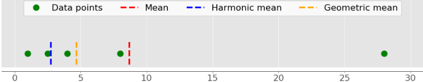

Рис. 2. Различные виды среднего значения

где `Data points` – значения элементов исходного массива.

Зеленые точки представляют точки данных 1, 2.5, 4, 8 и 28. Красная пунктирная линия – это среднее (арифметическое) значение. Синяя пунктирная линия – среднее гармоническое, а желтая – среднее геометрическое. Наглядно сравните существенную разницу в значениях средних величин.

Вы можете реализовать среднее геометрическое без использования библиотек следующим образом:

```python
x = [8.0, 1, 2.5, 4, 28.0]

gmean = 1
for item in x:
     gmean *= item
gmean **= 1 / len(x)
gmean
```

```
4.677885674856041
```

Значение среднего геометрического (4.67) в этом случае значительно отличается от значений арифметических (8.7, для справки – отображено на рисунке (Рис. 2)) и гармонических (2,76) средних для того же набора данных `x`.

Среднее геометрическое применяется в тех случаях, когда индивидуальные значения признака представляют собой относительные величины динамики, построенные в виде связанных величин, как отношение к предыдущему уровню каждого уровня в ряду динамики, т. е. характеризует средний коэффициент роста.

Ниже представлен пример использования доступного метода `geometric_mean()` в модуле `statistics` для вычисления геометрического среднего, который выполняет за программиста уже описанную последовательность действий и возвращает среднее геометрическое:

```python
gmean = statistics.geometric_mean(x)
gmean
```

```
4.67788567485604
```

У вас будет тот же результат, что и в предыдущем примере, но с минимальной ошибкой округления. Дело в том, что компьютер считает числа с плавающей точкой (дробные числа) с некоторой погрешностью (например, `print (0.1 + 0.1 + 0.1)` выведет `0.30000000000000004`). Кратно усугублять ситуацию и уменьшать точность может большое количество таких округлений.

Почему вообще возникает неточность – рассматривать не будем. Главное отметить, что необходимо использовать те средства, которые предназначены для решения соответствующих им задач.

В данном случае, лучше использовать готовый метод `statistics.geometric_mean()`, чем писать свой собственный код. Так же бывают ситуации, когда нам нужно использовать не общепринятое округление (округление в большую сторону), а банковское округление, чтобы избегать накопления ошибок. Но это не касается темы текущего материала и сообщено вам для расширения кругозора и самостоятельного изучения.

Если вы передаете данные со `NaN` значениями, тогда `statistics.geometric_mean()` будет вести себя как большинство аналогичных функций и вернёт `NaN` (англ. Not-a-Number, «не число»). Если есть хотя бы один 0, вернется 0.0 и будет показано предупреждение. Если вы укажете хотя бы одно отрицательное число, то получите `NaN` и предупреждение. Ниже показан пример, в котором в массиве есть одно `NaN` значение.

```python
import math

x_with_nan = [8.0, 1, 2.5, math.nan, 4, 28.0]
gmean = statistics.geometric_mean(x_with_nan)
gmean
```

```
nan
```

### Статистика при помощи модуля Scipy.Stats

Этот модуль содержит большое количество распределений вероятностей, сводную и частотную статистику, корреляционные функции и статистические тесты, маскированную статистику, ядерную оценку плотности, функциональность квази-Монте-Карло и многое другое.

Статистика – это очень обширная составляющая анализа данных, многие направления которых охватывает библиотека `SciPy`. Основные её функции представлены ниже:

- непрерывные распределения;
- многомерные распределения;
- дискретные распределения;
- сводные статистические данные;
- частотная статистика;
- корреляционные функции;
- статистические тесты;
- трансформации;
- статистические расстояния;
- случайная вариативная генерация;
- круговые статистические функции;
- функции таблицы непредвиденных обстоятельств;
- сюжет-тесты;
- функции скрытой статистики;
- одномерная и многомерная ядерная оценка плотности.

Полный список функциональности `Scipy.Stats` доступен на официальном сайте по url: https://docs.scipy.org/doc/scipy/reference/stats.html#summary-statistics .

`Scipy.Stats`, как и большинство `Python` библиотек, имеет обширное учебное пособие на английском языке, которое вы можете попробовать изучить самостоятельно по url: https://docs.scipy.org/doc/scipy/reference/tutorial/stats.html.

Давайте кратко рассмотрим выдержки из данного учебного пособия, адаптированные на русский язык. Рассмотрим работу со следующими функциями библиотеки `scipy`:

- дискретные статистические распределения;
- непрерывные статистические распределения.

#### Случайные переменные

Все статистические функции и доступные случайные величины находятся в суб-пакете `scipy.stats`.

В приведенных ниже примерах мы в основном будем сосредотачиваться на непрерывных случайных величинах (на англ. обозначаются как `RV`, т.е. Random Value – случайная величина).

Практически все рассматриваемое также может быть применимо и к дискретным переменным, но с некоторыми отличиями, о которых вы сможете самостоятельно почитать по следующему url: https://docs.scipy.org/doc/scipy/reference/tutorial/stats.html#discrete-points-label.

Для импорта базовой функциональности модуля `scipy.stats` воспользуемся следующим кодом:

```python
from scipy import stats
```

Многие объекты и функции вынесены в отдельные суб-модули суб-модуля `scipy.stats`, например, если нам нужно работать с нормальным распределением, мы можем импортировать его функциональность представленным ниже способом (т.е. некоторые отдельные объекты, такие как функциональность распределений, нужно дополнительно импортировать отдельно):

```python
#для работы с нормальным распределением
from scipy.stats import norm
```

#### Получение справки

Во-первых, все классы распределений сопровождаются вспомогательными функциями.

Для того, чтобы получить основную информацию о доступной в классе функциональности, мы можем использовать вызов «`print(stats.norm.doc)`», который выведет нам документацию суб-модуля, содержащего функциональность нормального распределения.

Например, используя встроенную документацию, мы можем узнать, что, чтобы найти область допустимых значений функции распределения (т.е. верхнюю и нижнюю границы распределения), мы можем использовать метод `norm.support()`, который вернет два значения – значение нижней и верхней границы:

```python
print('границы распределения: \nнижняя: %s, \nверхняя: %s' % norm.support())
```

```
границы распределения:
нижняя: -inf,
верхняя: inf
```

Вывести все доступные методы и свойства распределения можно с помощью вызова `dir(norm)`. Некоторые из методов являются внутренними и не доступны для вызова извне, т.е. используются для вычислений внутри класса (модуля распределения).

Ниже показано, что модуль, реализующий «нормальное распределение» содержит, например, метод вычисления медианы «`median()`», аналог которого мы уже использовали при работе с другими библиотеками.

```python
rv = norm()
dir(rv) # вывод доступных методов
```

```
['__class__',
 '__delattr__',
 '__dict__',
 '__dir__',
 '__doc__',
 '__eq__',
 '__format__',
 '__ge__',
 '__getattribute__',
 '__gt__',
 '__hash__',
 '__init__',
 '__init_subclass__',
 '__le__',
 '__lt__',
 '__module__',
 '__ne__',
 '__new__',
 '__reduce__',
 '__reduce_ex__',
 '__repr__',
 '__setattr__',
 '__sizeof__',
 '__str__',
 '__subclasshook__',
 '__weakref__',
 'a',
 'args',
 'b',
 'cdf',
 'dist',
 'entropy',
 'expect',
 'interval',
 'isf',
 'kwds',
 'logcdf',
 'logpdf',
 'logpmf',
 'logsf',
 'mean',
 'median',
 'moment',
 'pdf',
 'pmf',
 'ppf',
 'random_state',
 'rvs',
 'sf',
 'stats',
 'std',
 'support',
 'var']
```

Давайте получим список доступных распределений:

```python
dist_continu = [d for d in dir(stats) if isinstance(getattr(stats, d), stats.rv_continuous)]
dist_discrete = [d for d in dir(stats) if isinstance(getattr(stats, d), stats.rv_discrete)]

print('количество непрерывных распределений: %d' % len(dist_continu))
print('количество дискретных распределений: %d' % len(dist_discrete))
```

```
количество непрерывных распределений: 104
количество дискретных распределений: 19
```

Мы видим, что доступна работа с очень большим количеством функций распределения.

#### Общие методы

Основными общедоступными методами класса непрерывных случайных величин являются следующие методы, при помощи которых можно получить, например, кумулятивную функцию распределения случайных величин (`cdf`) или любую другую функцию или набор параметров из нижеперечисленных:

- `rvs` – получение случайных значений в указываемом в параметрах количестве;
- `pdf` – вычислить функцию плотности вероятности для ряда значений;
- `SF` – функция выживания (1-`CDF`);
- `ppf` – функция для вычисления точек плотности (поиск процентиля, обратная `CDF`);
- `isf` – обратная функция выживания (обратная `SF`);

где буквы в аббревиатурах: `d` – distribution, т.е. распределение с англ.; `f` – function, т.е. функция с англ.

В рамках данного учебного пособия не рассматривается теория статистики, поэтому её предлагается изучить самостоятельно. Однако далее мы рассмотрим некоторые простые аспекты работы с данными функциями.

#### Типы данных в статистическом анализе

Разделение данных на качественные и количественные – основополагающий принцип статистического анализа данных. Типы данных представлены на рисунке ниже (Рис. 3) и определяют какие статистические методы могут использоваться с ними. Например, вы должны анализировать непрерывные данные иначе, чем категориальные данные, потому что это в противоположном случае вы получите неправильный результат анализа. Поэтому, зная типы данных, с которыми вы имеете дело, вы сможете выбрать правильный метод анализа.

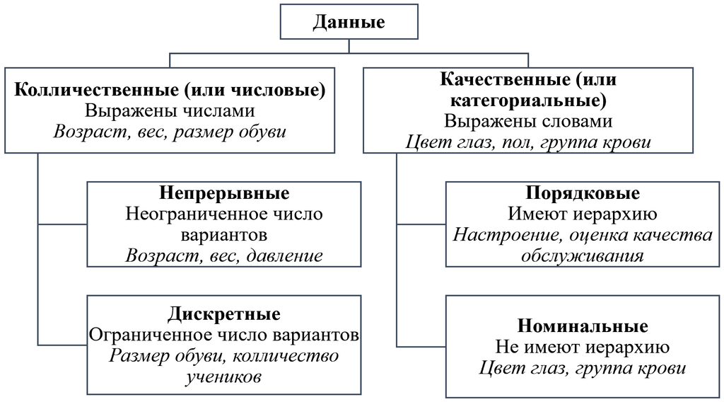

Рис. 3. Типы данных в статистическом анализе

Рассмотрим каждый тип данных в отношении того, какие статистические методы и инструменты визуализации можно к ним применять. Чтобы правильно понять, что мы сейчас будем рассматривать, вы должны понимать основы описательной статистики – т.е. значить следующие понятия: нормальное распределение, центральная тенденция (средняя, мода, медиана), меры изменчивости (диапазон, квартили), дисперсия и стандартное отклонение, модальность, перекос, эксцесс.

Для визуализации статистики наиболее часто используется три типа диаграмм, представленных на рисунке ниже (Рис. 4).

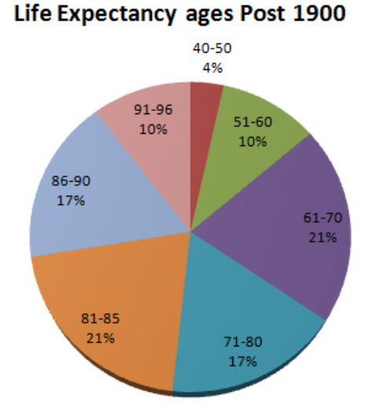

А) Круговая диаграмма

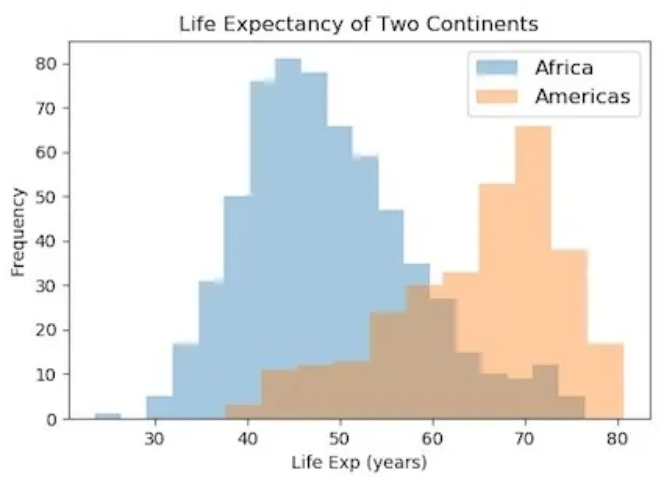

Б) Столбиковая диаграмма

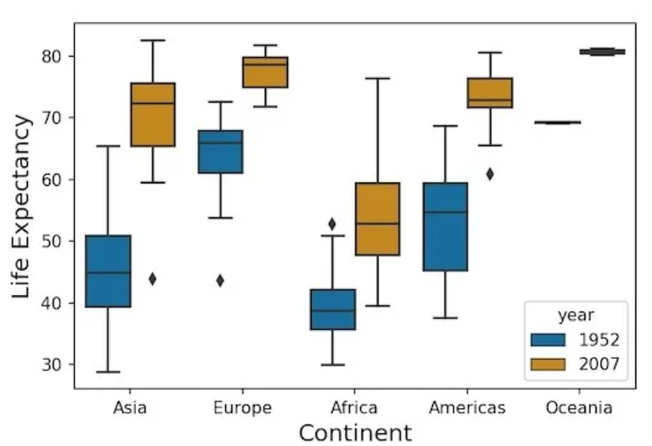

В) Диаграмма размаха

Рис. 4. Диаграммы в статистическом анализе

#### Номинальные данные

Когда вы имеете дело с номинальными данными, вы собираете информацию посредством определения частоты каких-либо вещей (например, как часто группа крови четвертая отрицательная) либо строите частоту в контексте доли от общего количества значений (можно выразить долю в процентном соотношении, например, 0% людей имеют пятую группу крови).

Номинальные данные можно посчитать (суммарное количество значений), можно определить процент от целого, однако нельзя вычислить среднее значение. Например, можно говорить о том, сколько продуктов в вашей корзине было взято в молочном отделе, или сколько процентов от покупок занимают овощи, но посчитать среднее количество конкретных типов товаров в вашей корзине невозможно – нельзя утверждать, что «в среднем, у меня в корзине 20% товаров занимает молоко», потому что у нас одна корзина.

Для визуализации номинальных данных часто используют круговую диаграмму или гистограмму (т.е. столбиковые диаграммы).

В случае, если доступны только две категории, данные относят к типу дихотомических (или бинарных, т.е. 0 или 1). Ответы на вопросы, требующие ответа «да-нет», – это и есть дихотомические данные. Если, делая покупки, вы собрали данные о том, продавался товар со скидкой или нет, это и будут дихотомические данные.

#### Порядковые данные

Когда вы имеете дело с порядковыми данными, вы можете использовать те же методы, что и с номинальными данными, но у вас в случаях, когда также есть доступ к некоторым дополнительным инструментам: вы связывать элементы ваших данных с частотами, пропорциями, процентами; а также использовать процентили, медианы, моды и межквартильный диапазон.

Наиболее часто используемые средства визуализации те же, что и у номинальных данных: круговые диаграммы и гистограммы (т.е. столбиковые диаграммы).

Например, вы можете в статистике настроения людей, или в статистике оценок учащихся, вычислять среднее настроение или среднюю оценку каждого человека, потому что эти примеры имеют как-бы несколько порядков «измеримости», в случае с настроением – оно каждый месяц у одного и того же человека разное, так и в случае с оценкой – она разная по каждому предмету.

Но возможность вычисления среднего, медианы и подобных показателей доступна не всегда. Например, если мы имеем данные анкет обратной связи, в которых производился опрос клиентов по поводу того, довольны ли они качеством обслуживания и довольны ли они вкусом блюд в ресторане, и при этом на выбор были варианты: «очень доволен, нейтрально, очень недоволен», то логически будет невозможно посчитать среднее количество клиентов, которые ответили «очень доволен». Мы можем лишь делать вывод типа «в среднем, клиенты довольны и количество довольных клиентов 60%», но не «в среднем довольно 60% клиентов».

Ситуацию так же усугубляет логическая неоднозначность веса ответов. Формулировка ответов схожа, и кажется, что линейно отражает степень удовлетворенности. Но по факту мы имеем три разных ответа, расценивание которых может накладывать ограничения на методы статистики. Часто встречаются и другие подобные спорные моменты.

#### Непрерывные данные

Когда вы имеете дело с непрерывными данными, вы можете использовать большинство из всех доступных методов для описания ваших данных.

Для визуализации непрерывных данных наиболее часто используют столбиковые диаграммы (гистограммы) или диаграммы размаха (или «ящик с усами», или на англ. box plot). С помощью гистограммы вы можете проверить центральную тенденцию, изменчивость, модальность (мода – это значение, которое случайная величина на заданном множестве наблюдений принимает наиболее часто) и эксцесс распределения (или на англ. kurtosis, мера остроты пика в распределении случайной величины, характеризует удаленность пика значений от средней величины).

Обратите внимание, что гистограмма в отличие от диаграммы размаха не может показать вам, если у вас есть какие-либо выбросы в данных.

#### Кумулятивная функция распределения (CDF)

Начнём изучение некоторых конкретных примеров работы с модулем статистики библиотеки `SciPy`. Рассмотрим кумулятивную функцию распределения (`CDF`, с англ. Cumulative Distribution Function). Она показывает вероятность того, что целевое значение меньше указанного значения либо равно ему. Она доступна только для количественных целевых значений.

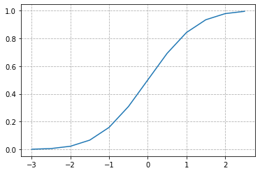

```
значения [-3.  -2.5 -2.  -1.5 -1.  -0.5  0.   0.5  1.   1.5  2.   2.5]
cdf [0.   0.01 0.02 0.07 0.16 0.31 0.5  0.69 0.84 0.93 0.98 0.99]
```

```python
import numpy as np
import matplotlib.pyplot as plt #библиотека для графиков
#выводить график внутристрочно
%matplotlib inline

x = np.arange(-3, 3, 0.5)
my_cdf = norm.cdf (x)

plt.plot(x, my_cdf)
plt.grid(linestyle='--') #добавить пунктирную сетку
plt.show() #показать график

print ('значения', x)
print ('cdf',my_cdf.round(2)) #округлим до 2 зн после ,
```

Рис. 5. Диаграмма `CDF`

Как видим на рисунке (Рис. 5), центр данной функции соответствует вероятности 0.5. Это значит, что с вероятностью 50% наше значение меньше или равно нулю (по определению кумулятивной функции), или, например, с вероятностью 0.99 значение числа в ряду значений меньше или равно 2.5, т.е. почти 100% (почти – потому что у нас шаг 0.5 в ряду, и происходит небольшая ошибка округления; т.е. если установите шаг, например 0.1, то значение `cdf` уже округлится в сторону 100%, что на самом деле более точно, чем 99%).

Обращаем внимание, что данные «`np.arange(-3, 3, 0.5)`» используются только для построения горизонтальной оси и не являются случайными величинами. Здесь мы использовали метод `cdf()` из класса нормального распределения. Поэтому и получили «идеальный» график `cdf` для нормального распределения с областью значений от -3 до 2.5.

#### Вывод графиков при помощи библиотеки matplotlib (и plotly)

Отметим, что в примере выше примере мы используем библиотеку `matplotlib` с целью создания графика. Это наиболее распространённая библиотека, решающая задачи визуализации данных на графиках и диаграммах.

Мы не будем отдельно изучать её или другие подобные библиотеки, но будем их часто использовать в дальнейшей работе. Поэтому рекомендуется самостоятельно изучить её путём экспериментов с передаваемыми ей параметрами.

Строка `«%matplotlib inline»` называется магической командой[2], встроенной в интерактивную оболочку `IPython` для языка программирования `Python`. При помощи данной строки мы указываем интерактивной оболочки, чтобы библиотека `matplotlib` выводила графики внутрь блокнота `Jupyther`.

[2] ☝🙂 Ознакомится со всеми встроенными магическими командами можно по url: https://ipython.readthedocs.io/en/stable/interactive/magics.html . Их довольно много.

Если написать, например, «`%matplotlib qt`», то графики будут выводится при помощи фреймворка графических интерфейсов `qt`, если он доступен в вашей операционной системе. Вы сможете взаимодействовать с графиком в отдельном окне (как показано на Рис. 6), а не в браузере.

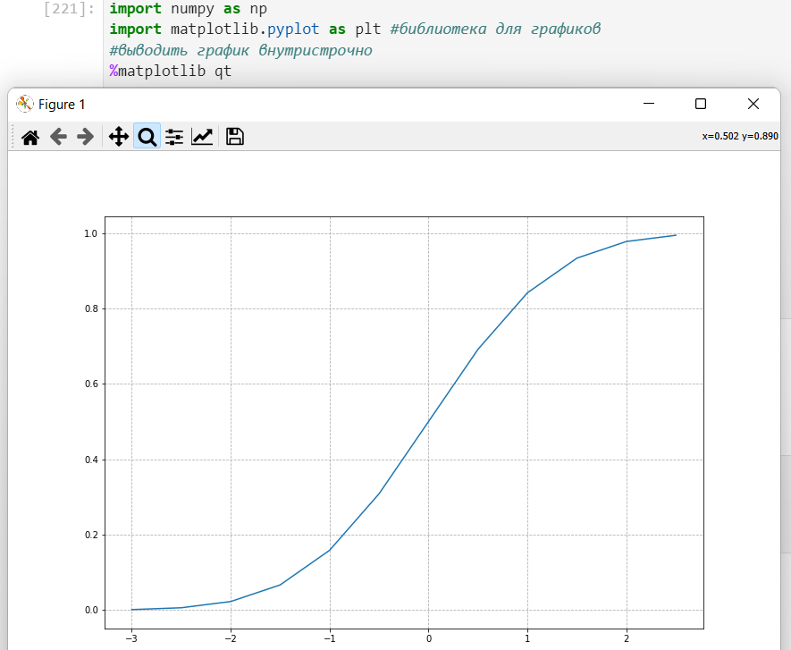

Рис. 6. Вывод `matplotlib` в `qt` окне

Стоит отметить, что, например, при помощи библиотеки `plotly` можно встраивать интерактивные графики внутрь вывода `Jupyter` блокнота, но это требует наличия расширения в `Jupyter`. В занятии по библиотеке `TensorFlow` для разнообразия будет использована именно библиотека `plotly` (для построения графиков).

В целом, далее будет представлено много различных применений библиотеки `matplotlib` и `plotly`, поэтому вы сможете изучить аспекты вывода диаграмм в непринуждённо–пассивном стиле обучения на практике.

#### NumPy в контексте Scipy. Кумулятивная функция распределения (CDF, продолжение)

Вы можете передавать как `NumPy` массивы в кумулятивную функцию (как было показано в примере выше), так и обычные `Python` массивы. Ниже показано, что результат генерации вероятностей одинаковый:

```python
print (norm.cdf([-3, 0, 3]))

import numpy as np
print (norm.cdf(np.array([-3, 0, 3])))
```

```
[0.0013499 0.5       0.9986501]
[0.0013499 0.5       0.9986501]
```

Так как многие методы возвращают `NumPy` массивы, то вы можете применять к ним уже рассмотренные (и встроенные в `NumPy`) методы, например – нахождение средних значений, отклонений, минимумов и максимумов – и др. показателей.

Несколько примеров таких методов продемонстрировано ниже.

```python
x = np.arange(-3, 3.5, 0.5) #"случайные" значения
c = norm.cdf(x) #значения процентилей
print ('▶x:', x)
print ('▶c:', c.round(2))
print('▶x.mean(), x.std(), x.var(), x.ptp():')
print (x.mean().round(2), x.std().round(2), x.var().round(2), x.ptp().round(2),sep=", ")
print('▶c.mean(), c.std(), c.var(), c.ptp():')
print (c.mean().round(2), c.std().round(2), c.var().round(2), c.ptp().round(2), sep=", ")
```

```
▶x: [-3.  -2.5 -2.  -1.5 -1.  -0.5  0.   0.5  1.   1.5  2.   2.5  3. ]
▶c: [0.   0.01 0.02 0.07 0.16 0.31 0.5  0.69 0.84 0.93 0.98 0.99 1.  ]
▶x.mean(), x.std(), x.var(), x.ptp():
0.0, 1.87, 3.5, 6.0
▶c.mean(), c.std(), c.var(), c.ptp():
0.5, 0.4, 0.16, 1.0
```

где:

- `x` – «случайные» значения. По факту они не случайные. Используются здесь просто как область значений для построения `cdf` нормального распределения;
- `c` – значения процентилей;

а следующие методы – встроенные в `NumPy` методы:

- `.mean()` – среднее арифметическое;
- `.std()` – стандартное отклонение;
- `.var()` – дисперсия, или разброс;
- `.ptp()` – размах.

Один из примеров – вывод среднего по рассчитанным значениям `cdf` (кумулятивной функции распределения) при помощи `c.mean()`.

По сути, вычисление значений кумулятивной функции распределения дает нам значения процентилей (по определению кумулятивной функции распределения). Только в виде десятичной дроби, т.е., например, 0.50 вместо 50%.

В примере видно, что среднее по «процентилям» `c.mean()` равно 0.5. Это логично, потому что взятые «случайные» значения в ряде `x` на самом деле не случайны и распределены равномерно (так как получены простой генерацией «`np.arange(-3, 3.5, 0.5)`», т.е. дискретно от -3 включительно до 3.5 не включительно с шагом 0.5).

Если бы «случайные» значения были бы сконцентрированы правее от значения медианы, то значение `c.mean()` было бы больше 0.5, как показано в примере ниже.

```python
x = np.arange(-3, 3.5, 0.5) #"случайные" значения
x = np.append(x, np.arange(1, 1.5, 0.1)) #увеличим количество значений.
#т.е. "уплотним" распределение правее медианы
x = np.sort(x) #отсортируем значения по возрастанию (это обязательно)
c = norm.cdf(x) #значения процентилей
print ('▶x:', x)
print('▶c.mean(), c.std(), c.var(), c.ptp():')
print (c.mean().round(2), c.std().round(2), c.var().round(2), c.ptp().round(2), sep=", ")
```

```
▶x: [-3.  -2.5 -2.  -1.5 -1.  -0.5  0.   0.5  1.   1.   1.1  1.2  1.3  1.4
  1.5  2.   2.5  3. ]
▶c.mean(), c.std(), c.var(), c.ptp():
0.61, 0.38, 0.15, 1.0
```

Чтобы найти медиану распределения, мы можем воспользоваться, например, уже известной нам `NumPy` функцией `np.median()`, передав в неё ряд значений.

Ниже будет продемонстрирован пример использования `np.median()`, а так же использование функции поиска значения процентиля (т.е. `ppf` функции, которая является обратной по отношению к `cdf`).

#### Функция получения значения процентиля (PPF)

`PPF` (расшифровывается с англ. как percent point function) – функция, используемая для получения значения, соответствующему определенному процентилю.

Например, как уже было сказано (последний абзац раздела «Процентили»), значение 50-ого процентиля соответствует значению медианы. То есть передав методу `norm.ppf()` 50–ый процентиль вы получите значение медианного среднего значения. Однако эта функция принимает числа в диапазоне от 0 до 1, а не от 0 до 100, поэтому, в случае с 50–ым процентилем указывайте «`norm.ppf(0.5)`» как в примере ниже:

```python
import numpy as np

x = np.arange(-3, 3.5, 0.5)
x = np.append(x, np.arange(1, 1.5, 0.1)) #увееличим колличество значений.
#т.е. "уплотним" распределение правее медианы
x = np.sort(x) #отсортируем значения по возрастанию (это обязательно)
print("▶x: ", x)

print ("▶np.median(x): ", np.median(x))

my_ppf = norm.ppf(0.5, loc= np.median(x), scale=x.std())
print ("▶norm.ppf(0.5), т.е. 50ый процентиль или медиана: ", my_ppf)

#np.percentile() и norm.ppf()
print (np.percentile(x,30,0), "не равно", norm.ppf(0.3, loc=np.median(x), scale=x.std()))
print ("т.к. norm.ppf() работает только с нормальным распределением")
```

```
▶x:  [-3.  -2.5 -2.  -1.5 -1.  -0.5  0.   0.5  1.   1.   1.1  1.2  1.3  1.4
  1.5  2.   2.5  3. ]
▶np.median(x):  1.0
▶norm.ppf(0.5), т.е. 50ый процентиль или медиана:  1.0
-0.4500000000000002 не равно 0.11903488514629679
т.к. norm.ppf() работает только с нормальным распределением
```

Обратите внимание, что ряд дискретных значений, сгенерированный от -3 до +3 с шагом 0.5 распределен по равномерному закону, а не по нормальному закону. Поэтому получение любых других значений процентилей (кроме медианного) будет давать неправильные значение процентилей. Про вызов «`norm.ppf(0.5, loc=np.median(x), scale=x.std())`», а точнее про параметры `loc` и `scale` (сдвиг и масштаб соответственно) будет рассмотрено на следующем занятии.

Согласитесь, что странно при помощи конструкции «`norm.ppf(0.5, loc=np.median(x), scale=x.std())`», уже содержащей медианное значение `np.median(x)`, получать это же медианное значение.

Дело в том, что если бы использованный ряд значений соответствовал нормальному закону распределения, то тогда как параметр сдвига мы бы указали среднее арифметическое значение, т.е. «`loc=x.mean()`».

Указывать медиану как параметр сдвига некорректно, но в примере выше так было сделано только для того, чтобы продемонстрировать работоспособность функции получения процентилей `ppf` из модуля для работы с нормальными распределениями на примере работы с рядом, распределенным не по нормальному закону распределения. Этот нюанс и работа со сдвигом и масштабом будет подробно рассмотрена на следующем занятии.

Так же на следующем занятии мы рассмотрим, как генерировать ряды случайных величин, распределенных по нормальному закону распределения, и закрепим полученные навыки на примере из реальной жизни.

## Контрольные задания и вопросы

1. Базовая функциональность `NumPy` – опишите доступные статистические функции. Повторите то же для встроенного модуля `statistics` – опишите доступные статистические функции.
2. Примеры применения среднеарифметического, медианы, среднегеометрического и гармонического среднего, процентилей.
3. Опишите типы данных в статистическом анализе. Приведите примеры.
4. Модуль `Scipy.Stats` – опишите доступные возможности для статистики.
5. Представьте код, который строит графики кумулятивной функции распределения (`cdf`), функции получения процентилей (`ppf`) и функции плотности вероятности (`pdf`) для сгенерированного при помощи `NumPy` набора дискретных значений от -3 до 3 с дискретностью 0.1 (как в примерах в занятии).

1. Проведите эксперименты с библиотекой для построения графиков `matplitlib`. Попробуйте добавить `label` для графиков, `xlabel/ylabel` для осей, `title` и для всего графика целиком. На следующем занятии будет представлено решение этих задач.